# **Credit Card Fraud Detection**

#### Author: Luis Rito Filipe

#### March, 2023

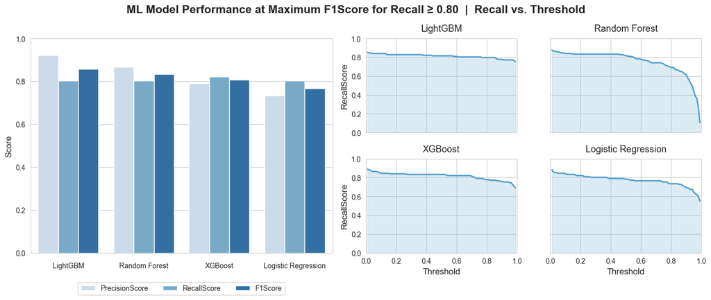

# Summary

The following study evaluates multiple machine learning algorithms for fraud detection on a highly imbalanced transaction dataset. The objective is to maximize the identification of fraudulent transactions while controlling false positives.

# About The Study

The objective of this study is to compare machine learning algorithms when applied to data analysis to uncover potential fraudulent credit card trasactions. To achieve this, I will leverage widely used Python libraries specialized in data analysis and machine learning, including tools for data manipulation, visualization, and predictive modeling. The study will progress from exploratory data analysis to more advanced techniques, such as feature engineering and fraud detection modeling, in order to provide meaningful insights into the characteristics of fraudulent transactions. For reasons of data anonymization, feature interpretation will be limited.

# About The Dataset

The following study uses a dataset of credit card transactions publicly available from Kaggle (see link below). The dataset is based on real transactions but has been anonymized, with features transformed using PCA to protect sensitive information.

Dataset link: https://www.kaggle.com/datasets/mlg-ulb/creditcardfraud

```python
import pandas as pd
import numpy as np
#import time
#import threading
#import csv, sqlite3
#import statistics
import matplotlib.pyplot as plt
import matplotlib.colors as mcolors
from matplotlib.colors import LinearSegmentedColormap, TwoSlopeNorm, Normalize
import matplotlib.gridspec as gridspec
#import plotly.graph_objects as go
from plotly.subplots import make_subplots
import seaborn as sns
#from datetime import date, timedelta
# from ibapi.client  import EClient
# from ibapi.wrapper import EWrapper
# from ibapi.contract import Contract
# from ibapi.ticktype import TickTypeEnum
from sklearn.preprocessing import StandardScaler
from sklearn.model_selection import train_test_split
from sklearn.linear_model import LogisticRegression
from sklearn.metrics import confusion_matrix, precision_score, recall_score, f1_score, precision_recall_curve, roc_auc_score, average_precision_score, matthews_corrcoef, log_loss, brier_score_loss
from sklearn.calibration import calibration_curve
from sklearn.model_selection import RandomizedSearchCV, StratifiedKFold
# from sklearn.svm import SVC
# from sklearn.tree import DecisionTreeClassifier
# from sklearn.neighbors import KNeighborsClassifier
from sklearn.ensemble import RandomForestClassifier
# from sklearn.neural_network import MLPClassifier
# from sklearn import metrics
from xgboost import XGBClassifier
from lightgbm import LGBMClassifier
import shap
import warnings

pd.set_option('display.max_rows', None)
pd.set_option('display.max_columns', None)
pd.set_option('display.max_colwidth', None)
warnings.filterwarnings("ignore")

def plot_confusion_matrix(y, y_predict):
    cm = confusion_matrix(y, y_predict)
    plt.figure(figsize=(4, 3))
    ax = sns.heatmap(cm, annot=True, fmt="d", cmap="Blues")
    ax.set_xlabel('Predicted labels', fontsize=11, labelpad=10)
    ax.set_ylabel('True labels', fontsize=11, labelpad=10)
    ax.set_title('Confusion Matrix', fontsize=13, pad=14, fontweight="bold")
    ax.xaxis.set_ticklabels(['Is not fraud', 'Is fraud'])
    ax.yaxis.set_ticklabels(['Is not fraud', 'Is fraud'])
    plt.tight_layout()
    plt.show()
```

# Methodology

- Exploratory Data Analysis and Feature Evaluation
- Model Training
- Model Comparison and Selection

# Exploratory Data Analysis and Feature Evaluation

The dataset consists of 31 features. The "Time" feature corresponds to the time in seconds when each transaction occured, the "Amount" feature is the amount of each transaction, and the "Class" feature is a flag that identifies each transaction with an integer, being zero if is not considered fraudulent, and one if fraudulent. The fraud rate is 0.1727%, indicating a highly imbalanced target variable ("Class"). The remaining features are named with a label from "V1" to "V28", their values are float type and cannot be interpreted by their label meaning. The "Time" feature in this dataset ranges from 0 to 172792 seconds, corresponding to approximately two days or 48 hours.

Below, the dataset summary statistics.

```python
df = pd.read_csv("creditcard.csv")
df.info(verbose=False)
```

```
<class 'pandas.core.frame.DataFrame'>
RangeIndex: 284807 entries, 0 to 284806
Columns: 31 entries, Time to Class
dtypes: float64(30), int64(1)
memory usage: 67.4 MB
```

```python
df.describe().round(3)
```

|  | Time | V1 | V2 | V3 | V4 | V5 | V6 | V7 | V8 | V9 | V10 | V11 | V12 | V13 | V14 | V15 | V16 | V17 | V18 | V19 | V20 | V21 | V22 | V23 | V24 | V25 | V26 | V27 | V28 | … |
| --- | --- | --- | --- | --- | --- | --- | --- | --- | --- | --- | --- | --- | --- | --- | --- | --- | --- | --- | --- | --- | --- | --- | --- | --- | --- | --- | --- | --- | --- | --- |
| count | 284807.000 | 284807.000 | 284807.000 | 284807.000 | 284807.000 | 284807.000 | 284807.000 | 284807.000 | 284807.000 | 284807.000 | 284807.000 | 284807.000 | 284807.000 | 284807.000 | 284807.000 | 284807.000 | 284807.000 | 284807.000 | 284807.000 | 284807.000 | 284807.000 | 284807.000 | 284807.000 | 284807.000 | 284807.000 | 284807.000 | 284807.000 | 284807.000 | 284807.000 | … |
| mean | 94813.860 | 0.000 | 0.000 | -0.000 | 0.000 | 0.000 | 0.000 | -0.000 | 0.000 | -0.000 | 0.000 | 0.000 | -0.000 | 0.000 | 0.000 | 0.000 | 0.000 | -0.000 | 0.000 | 0.000 | 0.000 | 0.000 | -0.000 | 0.000 | 0.000 | 0.000 | 0.000 | -0.000 | -0.000 | … |
| std | 47488.146 | 1.959 | 1.651 | 1.516 | 1.416 | 1.380 | 1.332 | 1.237 | 1.194 | 1.099 | 1.089 | 1.021 | 0.999 | 0.995 | 0.959 | 0.915 | 0.876 | 0.849 | 0.838 | 0.814 | 0.771 | 0.735 | 0.726 | 0.624 | 0.606 | 0.521 | 0.482 | 0.404 | 0.330 | … |
| min | 0.000 | -56.408 | -72.716 | -48.326 | -5.683 | -113.743 | -26.161 | -43.557 | -73.217 | -13.434 | -24.588 | -4.797 | -18.684 | -5.792 | -19.214 | -4.499 | -14.130 | -25.163 | -9.499 | -7.214 | -54.498 | -34.830 | -10.933 | -44.808 | -2.837 | -10.295 | -2.605 | -22.566 | -15.430 | … |
| 25% | 54201.500 | -0.920 | -0.599 | -0.890 | -0.849 | -0.692 | -0.768 | -0.554 | -0.209 | -0.643 | -0.535 | -0.762 | -0.406 | -0.649 | -0.426 | -0.583 | -0.468 | -0.484 | -0.499 | -0.456 | -0.212 | -0.228 | -0.542 | -0.162 | -0.355 | -0.317 | -0.327 | -0.071 | -0.053 | … |
| 50% | 84692.000 | 0.018 | 0.065 | 0.180 | -0.020 | -0.054 | -0.274 | 0.040 | 0.022 | -0.051 | -0.093 | -0.033 | 0.140 | -0.014 | 0.051 | 0.048 | 0.066 | -0.066 | -0.004 | 0.004 | -0.062 | -0.029 | 0.007 | -0.011 | 0.041 | 0.017 | -0.052 | 0.001 | 0.011 | … |
| 75% | 139320.500 | 1.316 | 0.804 | 1.027 | 0.743 | 0.612 | 0.399 | 0.570 | 0.327 | 0.597 | 0.454 | 0.740 | 0.618 | 0.663 | 0.493 | 0.649 | 0.523 | 0.400 | 0.501 | 0.459 | 0.133 | 0.186 | 0.529 | 0.148 | 0.440 | 0.351 | 0.241 | 0.091 | 0.078 | … |
| max | 172792.000 | 2.455 | 22.058 | 9.383 | 16.875 | 34.802 | 73.302 | 120.589 | 20.007 | 15.595 | 23.745 | 12.019 | 7.848 | 7.127 | 10.527 | 8.878 | 17.315 | 9.254 | 5.041 | 5.592 | 39.421 | 27.203 | 10.503 | 22.528 | 4.585 | 7.520 | 3.517 | 31.612 | 33.848 | … |

```python
print(f"Fraud rate: {(100 * df['Class'].mean()).round(2)}%")
```

```
Fraud rate: 0.17%
```

A feature named "Hour" was created for a better understanding if there is a pattern in a specific time of the day and also to enhance the predictive power of the models; this later proved to yield mixed results, depending on the machine learning algorithms.

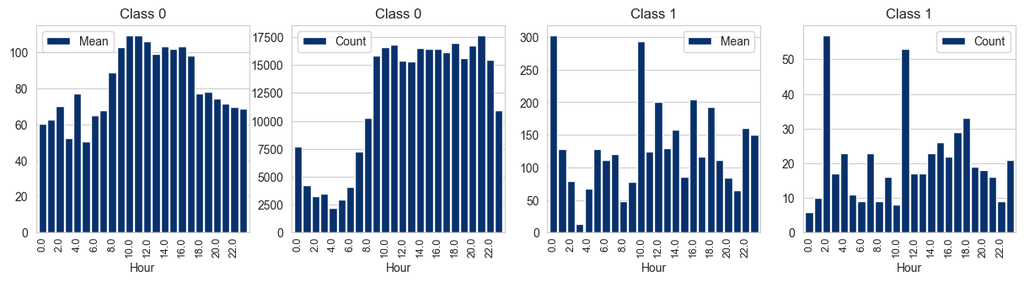

```python
df["Hour"] = (df["Time"] // 3600) % 24
def encapsulate():
    transactions = df.groupby(["Class", "Hour"]).agg(Mean=("Amount","mean"), Count=("Class","count")).sort_values(["Class", "Hour"], ascending=[False, True]).reset_index()
    fig, axes = plt.subplots(1, 4, figsize=(15, 3.2), sharey=False)
    color = "#08306b"
    transactions[transactions["Class"].eq(0)].plot( x="Hour", y="Mean", kind="bar", ax=axes[0], color=color, width=0.9, title="Class 0")
    transactions[transactions["Class"].eq(0)].plot( x="Hour", y="Count", kind="bar", ax=axes[1], color=color, width=0.9, title="Class 0")
    transactions[transactions["Class"].eq(1)].plot( x="Hour", y="Mean", kind="bar", ax=axes[2], color=color, width=0.9, title="Class 1")
    transactions[transactions["Class"].eq(1)].plot( x="Hour", y="Count", kind="bar", ax=axes[3], color=color, width=0.9, title="Class 1")
    for i in range(len(axes)):
        axes[i].grid(axis='x', visible=False)
        labels = axes[i].get_xticklabels()
        axes[i].set_xticklabels( [label.get_text() if idx % 2 == 0 else "" for idx, label in enumerate(labels)], rotation=90, ha='center', fontsize=9 )
        axes[i].tick_params(axis='x', length=0)
    plt.show()
encapsulate()
```

Higher average transaction amounts for fraudulent cases (Class = 1) are observed at hours 0 and 10, and these coincide with the lowest transaction counts. This may suggest that the elevated averages may be driven by a small number of high-value transactions. On the other hand, a higher transaction count is observed at hours 2 and 11 with average or below average amounts. While this could indicate potential fraud activity at these times, the number of days of this dataset is very limited to determine whether this pattern is stable or reproducible across multiple days.

In addition to the “Hour” feature, another engineered feature “Amt_z” was introduced, which represents the standardized (z-score) transaction amount. These features aim to capture temporal dynamics, relative magnitude, and deviations from typical transaction behavior, providing models with more informative signals than the original variables alone. The original “Time” feature was removed due to redundancy with the derived “Hour” feature, which resulted in a better performance for the tree models.

```python
df["Amt_z"] = (df["Amount"] - df["Amount"].mean()) / df["Amount"].std()
df = df.drop("Time", axis=1)
```

In the following histograms, a higher fraud rate is observed during night hours (see "Class" histogram). Additionally, multiple anonymized features exhibit greater variation during these periods, suggesting that fraudulent transactions are more concentrated in specific time windows.

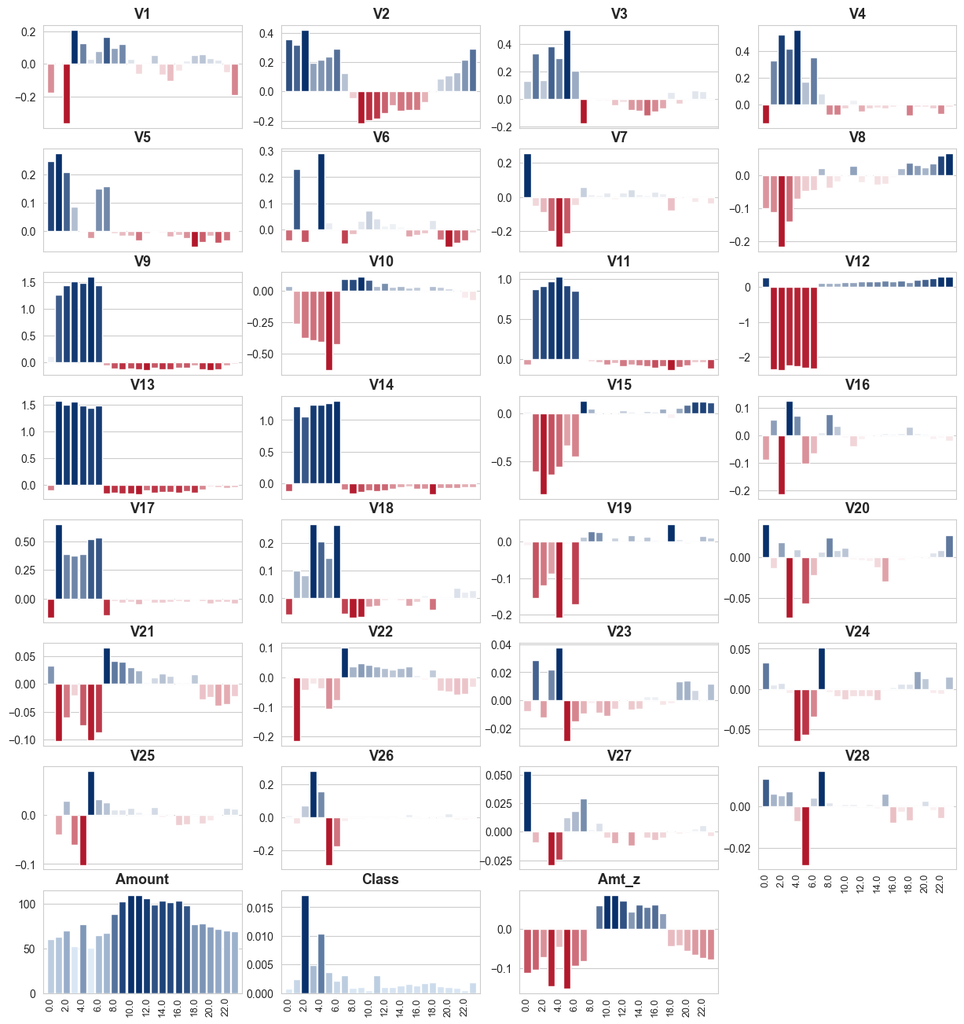

```python
def plot_one_feature_against_remaining_features(remove_features, main_feature):
    if remove_features is None:
        remove_features = []
    if isinstance(remove_features, str):
        remove_features = [remove_features]
    df_comp = df.drop(remove_features, axis=1).groupby(main_feature).mean(numeric_only=True)
    features = df_comp.columns
    n_features = len(features)
    cols = 4
    rows = int(np.ceil(n_features / cols))
    fig, axes = plt.subplots(rows, cols, figsize=(15, rows * 2), sharex=True)
    axes = axes.flatten()
    for i, feature in enumerate(features):
        full_cmap = LinearSegmentedColormap.from_list(
            "red_white_blue",
            ["#b2182b", "#ffffff", "#08306b"]
        )
        def get_colors(values):
            vmin, vmax = values.min(), values.max()

            if vmin < 0 and vmax > 0:
                norm = TwoSlopeNorm(vmin=vmin, vcenter=0, vmax=vmax)
                cmap = full_cmap
            elif vmin >= 0:
                norm = Normalize(vmin=vmin, vmax=vmax)
                cmap = LinearSegmentedColormap.from_list(
                    "white_blue",
                    ["#DEEBF7", "#08306B"]
                )
            else:
                norm = Normalize(vmin=vmin, vmax=vmax)
                cmap = LinearSegmentedColormap.from_list(
                    "red_white",
                    ["#B2182B", "#DEEBF7"]
                )
            return cmap(norm(values))

        values = df_comp[feature].values
        colors = get_colors(df_comp[feature])

        axes[i].bar(df_comp.index, values, color=colors, width=0.9)
        axes[i].set_title(feature, fontsize=13, fontweight="bold")
        ticks = range(0, len(df_comp.index), 2)
        axes[i].set_xticks(ticks)
        axes[i].set_xticklabels(df_comp.index[::2], fontsize=9)
        axes[i].margins(x=0.02)
        axes[i].tick_params(axis='x', rotation=90, length=0)
        axes[i].grid(axis='x', visible=False)
        axes[i].set_ylabel(None)
    for j in range(i + 1, len(axes)):
        fig.delaxes(axes[j])

    # for ax in axes:
    #     ax.tick_params(labelbottom=False)

    n_cols = 4

    for col in range(n_cols):
        col_axes = axes[col::n_cols]
        col_axes = [ax for ax in col_axes if ax in fig.axes]
        if col_axes:
            last_ax = col_axes[-1]
            last_ax.tick_params(labelbottom=True)

    plt.show()

plot_one_feature_against_remaining_features(remove_features=None, main_feature="Hour")
```

It is important to note that correlation measures linear relationships only and does not capture potential nonlinear interactions between variables. Therefore, features with low correlation may still contribute to model performance when combined with other variables or when nonlinear effects are considered.

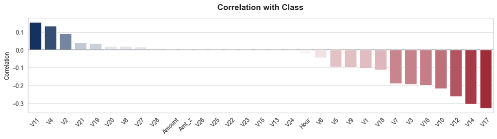

```python
def plot_feature_correlation():
    corr = df.corr()["Class"].drop("Class").sort_values(ascending=False)
    sns.set_style("whitegrid")

    full_cmap = LinearSegmentedColormap.from_list(
        "red_white_blue",
        ["#b2182b", "#ffffff", "#08306b"]
    )
    def get_colors(values):
        vmin, vmax = values.min(), values.max()

        if vmin < 0 and vmax > 0:
            norm = TwoSlopeNorm(vmin=vmin, vcenter=0, vmax=vmax)
            cmap = full_cmap
        elif vmin >= 0:
            norm = Normalize(vmin=vmin, vmax=vmax)
            cmap = LinearSegmentedColormap.from_list(
                "white_blue",
                ["#DEEBF7", "#08306B"]
            )
        else:
            norm = Normalize(vmin=vmin, vmax=vmax)
            cmap = LinearSegmentedColormap.from_list(
                "red_white",
                ["#B2182B", "#DEEBF7"]
            )
        return list(cmap(norm(values)))

    values = corr.values
    colors = get_colors(values)

    fig, ax = plt.subplots(figsize=(13, 3.2))

    sns.barplot(
        x=corr.index,
        y=corr.values,
        hue=corr.index,
        palette=colors,
        legend=False,
        ax=ax
    )

    ax.tick_params(axis='x', rotation=45)
    ax.set_title("Correlation with Class", fontsize=14, fontweight="bold", pad=14)
    ax.set_xlabel(None)
    ax.set_ylabel("Correlation")
    ax.axhline(y=0, color="black", linewidth=0.3)

    fig.canvas.draw()
    renderer = fig.canvas.get_renderer()
    max_height_px = max(
        label.get_window_extent(renderer=renderer).height
        for label in ax.get_xticklabels()
    )
    dpi = fig.dpi
    extra_height_inch = max_height_px / dpi
    fig.set_size_inches(12, 3 + extra_height_inch)

    plt.tight_layout()
    plt.show()

plot_feature_correlation()
```

# Model Training

In the next step, the dataset is split into training and testing sets to allow proper training of the classification models and unbiased evaluation of their performance.

```python
models = dict()
X = df.drop("Class", axis=1)
Y = df["Class"]

X_train, X_test, Y_train, Y_test = train_test_split(X, Y, test_size=0.33, random_state=42, stratify=Y)

print('X_train.shape=', X_train.shape, 'Y_train.shape=', Y_train.shape)
print('X_test.shape=', X_test.shape, 'Y_test.shape=', Y_test.shape)
```

```
X_train.shape= (190820, 31) Y_train.shape= (190820,)
X_test.shape= (93987, 31) Y_test.shape= (93987,)
```

## Logistic Regression

Logistic Regression is a supervised machine learning algorithm used for classification tasks, particularly binary classification problems where the target variable takes values such as 0/1, true/false, or yes/no. In this study, it is applied to predict the "Class" variable, which indicates whether a transaction is fraudulent or not. Despite its simplicity, Logistic Regression can perform well in high-dimensional datasets and provide a strong baseline for comparison with more complex models. Given the large number of observations relative to the number of features in this dataset, the model is less likely to overfit, although regularization and class imbalance handling remain important considerations. Class weights are incorporated to address the strong imbalance between fraudulent and non-fraudulent transactions. The coefficients of the Logistic Regression model provide insight into the direction and relative importance of each feature. Positive values indicate an increase in the likelihood of a transaction being classified as fraudulent, while negative values indicate the opposite. The magnitude of the coefficients reflects the strength of the relationship. Below is the implementation of Logistic Regression with hyperparameter tuning, with emphasis on the adjustment of class weights.

```python
def run_logistic_regression():
    scaler = StandardScaler()
    X_train_scaled = scaler.fit_transform(X_train)
    X_test_scaled = scaler.transform(X_test)

    parameters = {
            "solver": ['lbfgs'],
            "class_weight": [{0:1, 1:w} for w in range(1, 16)],
            "C": [0.01, 0.1, 1],
            "max_iter": [1000]
        }

    lr = LogisticRegression()

    cv = RandomizedSearchCV(
        estimator=lr,
        param_distributions=parameters,
        scoring={"recall": "recall", "f1": "f1", "precision": "precision"},
        refit="f1",
        cv=StratifiedKFold(n_splits=10, shuffle=True, random_state=42),
        verbose=1,
        random_state=42,
        n_jobs=-1
    )

    cv.fit(X_train_scaled, Y_train)
    best_model = cv.best_estimator_
    proba = best_model.predict_proba(X_test_scaled)[:, 1]

    results = []
    for t in np.linspace(0.0, 1.0, 101):
        y_pred = (proba >= t)
        cm = confusion_matrix(Y_test, y_pred)
        results.append({
            "Threshold": t,
            "PrecisionScore": precision_score(Y_test, y_pred, zero_division=0),
            "RecallScore": recall_score(Y_test, y_pred, zero_division=0),
            "F1Score": f1_score(Y_test, y_pred, zero_division=0),
            "TP": cm[1, 1],
            "TN": cm[0, 0],
            "FP": cm[0, 1],
            "FN": cm[1, 0],
            "MCC": matthews_corrcoef(Y_test, y_pred)
        })

    df_metrics = pd.DataFrame(results)
    df_metrics.to_csv("log_regression_metrics.csv", index=False)
    df_cv_results = pd.DataFrame(cv.cv_results_)
    df_cv_results.to_csv("log_regression_cv_results.csv", index=False)

    coefficients = best_model.coef_[0]
    feature_names = X.columns
    df_coef = pd.DataFrame({
        "Feature": feature_names,
        "Coefficient": coefficients
    })
    df_coef = df_coef.sort_values("Coefficient", ascending=False).round(3).reset_index(drop=True).transpose()

    return { "metrics": df_metrics, "best_params": cv.best_params_, "best_model": best_model, "coefficients": df_coef, "cv_results": df_cv_results, "y_pred": y_pred, "y_proba": proba }

log_regression = run_logistic_regression()
models.update({"Logistic Regression": log_regression})
```

```python
log_regression["metrics"].iloc[50:55]
```

|  | Threshold | PrecisionScore | RecallScore | F1Score | TP | TN | FP | FN | MCC |
| --- | --- | --- | --- | --- | --- | --- | --- | --- | --- |
| 50 | 0.50 | 0.755952 | 0.783951 | 0.769697 | 127 | 93784 | 41 | 35 | 0.769420 |
| 51 | 0.51 | 0.755952 | 0.783951 | 0.769697 | 127 | 93784 | 41 | 35 | 0.769420 |
| 52 | 0.52 | 0.754491 | 0.777778 | 0.765957 | 126 | 93784 | 41 | 36 | 0.765636 |
| 53 | 0.53 | 0.753012 | 0.771605 | 0.762195 | 125 | 93784 | 41 | 37 | 0.761836 |
| 54 | 0.54 | 0.753012 | 0.771605 | 0.762195 | 125 | 93784 | 41 | 37 | 0.761836 |

The following table shows the computed feature coefficients ordered from highest to lowest.

```python
log_regression["coefficients"]
```

|  | 0 | 1 | 2 | 3 | 4 | 5 | 6 | 7 | 8 | 9 | 10 | 11 | 12 | 13 | 14 | 15 | 16 | 17 | 18 | 19 | 20 | 21 | 22 | 23 | 24 | 25 | 26 | 27 | 28 | … |
| --- | --- | --- | --- | --- | --- | --- | --- | --- | --- | --- | --- | --- | --- | --- | --- | --- | --- | --- | --- | --- | --- | --- | --- | --- | --- | --- | --- | --- | --- | --- |
| Feature | V4 | V22 | V1 | V21 | V11 | V24 | Hour | V5 | Amt_z | Amount | V17 | V25 | V2 | V28 | V3 | V26 | V18 | V23 | V9 | V19 | V27 | V15 | V7 | V6 | V20 | V8 | V12 | V16 | V13 | … |
| Coefficient | 1.153 | 0.35 | 0.253 | 0.213 | 0.211 | 0.143 | 0.142 | 0.138 | 0.091 | 0.091 | 0.054 | 0.047 | 0.017 | 0.003 | -0.005 | -0.039 | -0.055 | -0.06 | -0.083 | -0.086 | -0.132 | -0.133 | -0.157 | -0.165 | -0.234 | -0.278 | -0.345 | -0.363 | -0.376 | … |

The table above indicates that higher values of the engineered features “Hour” and “Amt_z” are associated with an increased likelihood of belonging to the positive class, as reflected by their positive coefficients in the Logistic Regression model. A confusion matrix is shown below for a minimum probability equal to the threshold corresponding to the maximum F1Score for a RecallScore equal or higher than 0.8.

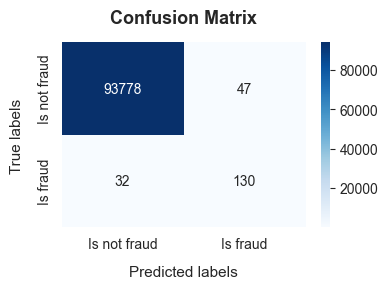

```python
plot_confusion_matrix(Y_test, log_regression["y_proba"] >= log_regression["metrics"][log_regression["metrics"]["RecallScore"] >= 0.8].sort_values("F1Score", ascending=False)["Threshold"].iloc[0])
```

## Random Forest

Random Forest is often expected to outperform Logistic Regression in fraud detection tasks, as it can capture nonlinear patterns, interactions between features, and is generally more robust regarding noise. However, its performance in highly imbalanced datasets is not guaranteed, and it may still struggle to detect minority class instances without appropriate tuning. The Random Forest hyperparameter search was optimized to reduce computational cost/time by limiting tree complexity and reducing cross-validation folds, while preserving model comparability across experiments.

```python
def run_random_forest():
    parameters = {
            "class_weight": [{0:1, 1:w} for w in range(1, 16)],
            "n_estimators": [200],
            "max_depth": [5, 15],
            "min_samples_leaf": [5],
            "max_features": ["sqrt"]
        }

    rf = RandomForestClassifier( random_state=42, n_jobs=-1 )

    cv = RandomizedSearchCV(
        estimator=rf,
        param_distributions=parameters,
        n_iter=6,
        scoring={"recall": "recall", "f1": "f1", "precision": "precision"},
        refit="recall",
        cv=StratifiedKFold(n_splits=2, shuffle=True, random_state=42),
        verbose=1,
        random_state=42,
        n_jobs=-1
    )

    cv.fit(X_train, Y_train)
    best_model = cv.best_estimator_
    proba = best_model.predict_proba(X_test)[:, 1]

    results = []
    for t in np.linspace(0.0, 1.0, 101):
        y_pred = (proba >= t)
        cm = confusion_matrix(Y_test, y_pred)
        results.append({
            "Threshold": t,
            "PrecisionScore": precision_score(Y_test, y_pred, zero_division=0),
            "RecallScore": recall_score(Y_test, y_pred, zero_division=0),
            "F1Score": f1_score(Y_test, y_pred, zero_division=0),
            "TP": cm[1, 1],
            "TN": cm[0, 0],
            "FP": cm[0, 1],
            "FN": cm[1, 0],
            "MCC": matthews_corrcoef(Y_test, y_pred)
        })

    df_metrics = pd.DataFrame(results)
    df_metrics.to_csv("random_forest_metrics.csv", index=False)
    df_cv_results = pd.DataFrame(cv.cv_results_)
    df_cv_results.to_csv("random_forest_cv_results.csv", index=False)

    importances = best_model.feature_importances_
    df_importances = pd.DataFrame({
        "Feature": X.columns,
        "Importance": importances
    })
    df_importances = df_importances.sort_values("Importance", ascending=False).round(3).reset_index(drop=True).transpose()

    return { "metrics": df_metrics, "best_params": cv.best_params_, "best_model": best_model, "importances": df_importances, "cv_results": df_cv_results, "y_pred": y_pred, "y_proba": proba }

random_forest = run_random_forest()
models.update({"Random Forest": random_forest})
```

```python
random_forest["metrics"].iloc[50:55]
```

|  | Threshold | PrecisionScore | RecallScore | F1Score | TP | TN | FP | FN | MCC |
| --- | --- | --- | --- | --- | --- | --- | --- | --- | --- |
| 50 | 0.50 | 0.840764 | 0.814815 | 0.827586 | 132 | 93800 | 25 | 30 | 0.827395 |
| 51 | 0.51 | 0.840764 | 0.814815 | 0.827586 | 132 | 93800 | 25 | 30 | 0.827395 |
| 52 | 0.52 | 0.839744 | 0.808642 | 0.823899 | 131 | 93800 | 25 | 31 | 0.823748 |
| 53 | 0.53 | 0.845161 | 0.808642 | 0.826498 | 131 | 93801 | 24 | 31 | 0.826408 |
| 54 | 0.54 | 0.860927 | 0.802469 | 0.830671 | 130 | 93804 | 21 | 32 | 0.830904 |

The following table shows the computed feature importance ordered from highest to lowest.

```python
random_forest["importances"]
```

|  | 0 | 1 | 2 | 3 | 4 | 5 | 6 | 7 | 8 | 9 | 10 | 11 | 12 | 13 | 14 | 15 | 16 | 17 | 18 | 19 | 20 | 21 | 22 | 23 | 24 | 25 | 26 | 27 | 28 | … |
| --- | --- | --- | --- | --- | --- | --- | --- | --- | --- | --- | --- | --- | --- | --- | --- | --- | --- | --- | --- | --- | --- | --- | --- | --- | --- | --- | --- | --- | --- | --- |
| Feature | V14 | V17 | V10 | V12 | V11 | V16 | V4 | V3 | V9 | V18 | V7 | V2 | V5 | V21 | V1 | V6 | V8 | V19 | V20 | Amt_z | Amount | V26 | V27 | V28 | V22 | V15 | V23 | V25 | V13 | … |
| Importance | 0.223 | 0.181 | 0.124 | 0.117 | 0.082 | 0.059 | 0.049 | 0.024 | 0.021 | 0.02 | 0.019 | 0.009 | 0.008 | 0.008 | 0.005 | 0.005 | 0.004 | 0.004 | 0.004 | 0.004 | 0.003 | 0.003 | 0.003 | 0.003 | 0.003 | 0.003 | 0.002 | 0.002 | 0.002 | … |

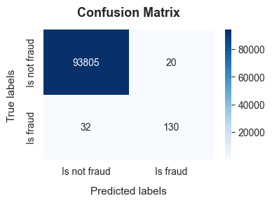

```python
plot_confusion_matrix(Y_test, random_forest["y_proba"] >= random_forest["metrics"][random_forest["metrics"]["RecallScore"] >= 0.8].sort_values("F1Score", ascending=False)["Threshold"].iloc[0])
```

## XGBoost

XGBoost is often expected to outperform Logistic Regression and Random Forest in fraud detection tasks, as it handles extreme imbalance, learns subtle patterns and focuses on misclassified fraud cases. Reducing the subsample and colsample_bytree (min ≥ 0.7) from default values (1.0) introduces randomness, reduces overfitting, improves generalization, forces feature diversity and reduces dominance of strong features. Shares some similarities with Random Forest. But while the later builds trees during training and outputs the average of the predictions from individual trees, XGBoost builds new trees sequentially and each new tree corrects errors from the previous tree, improving model's predictions.

```python
def run_xgboost():
    scale_pos_weight = len(Y_train[Y_train.eq(0)]) / len(Y_train[Y_train.eq(1)])

    parameters = {
        "n_estimators": [200, 300, 400],
        "max_depth": [0],
        "learning_rate": [0.01, 0.02, 0.05],
        "subsample": [0.7, 0.8, 0.9],
        "colsample_bytree": [0.7, 0.8, 0.9],
        "scale_pos_weight": [scale_pos_weight*0.5, scale_pos_weight, scale_pos_weight*1.5]
    }

    xgb = XGBClassifier( random_state=42, n_jobs=-1, eval_metric="logloss" )

    cv = RandomizedSearchCV(
        estimator=xgb,
        param_distributions=parameters,
        n_iter=20,
        scoring={"recall": "recall", "f1": "f1", "precision": "precision"},
        refit="recall",
        cv=StratifiedKFold(n_splits=3, shuffle=True, random_state=42),
        verbose=1,
        random_state=42,
        n_jobs=-1
    )

    cv.fit(X_train, Y_train)
    best_model = cv.best_estimator_
    proba = best_model.predict_proba(X_test)[:, 1]

    results = []
    for t in np.linspace(0.0, 1.0, 101):
        y_pred = (proba >= t)
        cm = confusion_matrix(Y_test, y_pred)
        results.append({
            "Threshold": t,
            "PrecisionScore": precision_score(Y_test, y_pred, zero_division=0),
            "RecallScore": recall_score(Y_test, y_pred, zero_division=0),
            "F1Score": f1_score(Y_test, y_pred, zero_division=0),
            "TP": cm[1, 1],
            "TN": cm[0, 0],
            "FP": cm[0, 1],
            "FN": cm[1, 0],
            "MCC": matthews_corrcoef(Y_test, y_pred)
        })

    df_metrics = pd.DataFrame(results)
    df_metrics.to_csv("xgboost_metrics.csv", index=False)
    df_cv_results = pd.DataFrame(cv.cv_results_)
    df_cv_results.to_csv("xgboost_cv_results.csv", index=False)

    importances = best_model.get_booster().get_score(importance_type="gain")
    df_importances = pd.DataFrame({
        "Feature": X.columns
    })
    df_importances["Importance"] = df_importances["Feature"].map(importances).fillna(0)
    df_importances = df_importances.sort_values("Importance", ascending=False).round().reset_index(drop=True).transpose()

    return { "metrics": df_metrics, "best_params": cv.best_params_, "best_model": best_model, "importances": df_importances, "cv_results": df_cv_results, "y_pred": y_pred, "y_proba": proba }

xgboost = run_xgboost()
models.update({"XGBoost": xgboost})
```

```python
xgboost["metrics"].iloc[50:55]
```

|  | Threshold | PrecisionScore | RecallScore | F1Score | TP | TN | FP | FN | MCC |
| --- | --- | --- | --- | --- | --- | --- | --- | --- | --- |
| 50 | 0.50 | 0.737705 | 0.833333 | 0.782609 | 135 | 93777 | 48 | 27 | 0.783669 |
| 51 | 0.51 | 0.745856 | 0.833333 | 0.787172 | 135 | 93779 | 46 | 27 | 0.787998 |
| 52 | 0.52 | 0.750000 | 0.833333 | 0.789474 | 135 | 93780 | 45 | 27 | 0.790190 |
| 53 | 0.53 | 0.752809 | 0.827160 | 0.788235 | 134 | 93781 | 44 | 28 | 0.788729 |
| 54 | 0.54 | 0.751412 | 0.820988 | 0.784661 | 133 | 93781 | 44 | 29 | 0.785044 |

The following table shows the computed feature importance from highest to lowest.

```python
xgboost["importances"]
```

|  | 0 | 1 | 2 | 3 | 4 | 5 | 6 | 7 | 8 | 9 | 10 | 11 | 12 | 13 | 14 | 15 | 16 | 17 | 18 | 19 | 20 | 21 | 22 | 23 | 24 | 25 | 26 | 27 | 28 | … |
| --- | --- | --- | --- | --- | --- | --- | --- | --- | --- | --- | --- | --- | --- | --- | --- | --- | --- | --- | --- | --- | --- | --- | --- | --- | --- | --- | --- | --- | --- | --- |
| Feature | V14 | V10 | V4 | V17 | V20 | V12 | Amount | Amt_z | V21 | V19 | V8 | V3 | V23 | V26 | V13 | V28 | Hour | V22 | V6 | V11 | V5 | V15 | V16 | V25 | V24 | V1 | V18 | V7 | V2 | … |
| Importance | 6434.0 | 2547.0 | 1577.0 | 682.0 | 583.0 | 571.0 | 486.0 | 469.0 | 406.0 | 394.0 | 378.0 | 279.0 | 265.0 | 264.0 | 254.0 | 254.0 | 252.0 | 244.0 | 243.0 | 241.0 | 238.0 | 233.0 | 215.0 | 212.0 | 202.0 | 202.0 | 201.0 | 197.0 | 187.0 | … |

The table above shows that XGboost also attributed high importance to features V14 and V10, a relative importance to engineered feature "Amt_z" and low importance to "Hour" features. A confusion matrix is shown below for a minimum probability equal to the threshold corresponding to the maximum F1Score for a RecallScore equal or higher than 0.8.

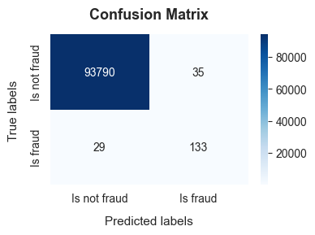

```python
plot_confusion_matrix(Y_test, xgboost["y_proba"] >= xgboost["metrics"][xgboost["metrics"]["RecallScore"] >= 0.8].sort_values("F1Score", ascending=False)["Threshold"].iloc[0])
```

## LightGBM

LightGBM is a high-performance gradient boosting framework built on decision tree algorithms. It is widely used for ranking, classification, and many other machine learning tasks. Works particularly well with large datasets and a large number of independent variables, optimizing heavily for speed and memory efficiency. LightGBM grows trees leaf-wise, evaluates all leaves and expands the single leaf that reduces the loss the most. It uses histogram-based algorithms to group continuous feature values into discrete bins. This drastically reduces memory usage and speeds up training. It can handle categorical features directly without requiring to manually apply encoding first. Because leaf-wise growth is quite aggressive, LightGBM can easily overfit, especially on smaller datasets. To prevent this, careful tuning of hyperparameters like max_depth, num_leaves, and min_data_in_leaf is strictly required.

```python
def run_light_gbm():
    scale_pos_weight = len(Y_train[Y_train.eq(0)]) / len(Y_train[Y_train.eq(1)])

    parameters = {
        "n_estimators": [200, 300, 400],
        "max_depth": [-1], # -1 = sem restrições
        "num_leaves": [31, 63, 127],
        "learning_rate": [0.01, 0.02, 0.05],
        "subsample": [0.7, 0.8, 0.9],
        "colsample_bytree": [0.7, 0.8, 0.9],
        "scale_pos_weight": [scale_pos_weight*0.5, scale_pos_weight, scale_pos_weight*1.5]
    }

    lgbm = LGBMClassifier( random_state=42, n_jobs=-1 )

    cv = RandomizedSearchCV(
        estimator=lgbm,
        param_distributions=parameters,
        n_iter=20,
        scoring={"recall": "recall", "f1": "f1", "precision": "precision"},
        refit="f1",
        cv=StratifiedKFold(n_splits=3, shuffle=True, random_state=42),
        verbose=1,
        random_state=42,
        n_jobs=-1
    )

    cv.fit(X_train, Y_train)
    best_model = cv.best_estimator_
    proba = best_model.predict_proba(X_test)[:, 1]

    results = []
    for t in np.linspace(0.0, 1.0, 101):
        y_pred = (proba >= t)
        cm = confusion_matrix(Y_test, y_pred)
        results.append({
            "Threshold": t,
            "PrecisionScore": precision_score(Y_test, y_pred, zero_division=0),
            "RecallScore": recall_score(Y_test, y_pred, zero_division=0),
            "F1Score": f1_score(Y_test, y_pred, zero_division=0),
            "TP": cm[1, 1],
            "TN": cm[0, 0],
            "FP": cm[0, 1],
            "FN": cm[1, 0],
            "MCC": matthews_corrcoef(Y_test, y_pred)
        })

    df_metrics = pd.DataFrame(results)
    df_metrics.to_csv("light_gbm_metrics.csv", index=False)
    df_cv_results = pd.DataFrame(cv.cv_results_)
    df_cv_results.to_csv("light_gbm_cv_results.csv", index=False)

    df_importances = pd.DataFrame({
        "Feature": X.columns,
        "Importance": best_model.booster_.feature_importance(importance_type="gain")
    })
    df_importances = df_importances.sort_values("Importance", ascending=False).round().reset_index(drop=True).transpose()

    return { "metrics": df_metrics, "best_params": cv.best_params_, "best_model": best_model, "importances": df_importances, "cv_results": df_cv_results, "y_pred": y_pred, "y_proba": proba }

light_gbm = run_light_gbm()
models.update({"LightGBM": light_gbm})
```

```python
light_gbm["metrics"].iloc[50:55]
```

|  | Threshold | PrecisionScore | RecallScore | F1Score | TP | TN | FP | FN | MCC |
| --- | --- | --- | --- | --- | --- | --- | --- | --- | --- |
| 50 | 0.50 | 0.891892 | 0.814815 | 0.851613 | 132 | 93809 | 16 | 30 | 0.852241 |
| 51 | 0.51 | 0.891892 | 0.814815 | 0.851613 | 132 | 93809 | 16 | 30 | 0.852241 |
| 52 | 0.52 | 0.891892 | 0.814815 | 0.851613 | 132 | 93809 | 16 | 30 | 0.852241 |
| 53 | 0.53 | 0.891892 | 0.814815 | 0.851613 | 132 | 93809 | 16 | 30 | 0.852241 |
| 54 | 0.54 | 0.891892 | 0.814815 | 0.851613 | 132 | 93809 | 16 | 30 | 0.852241 |

The following table shows the computed feature importance from highest to lowest.

```python
light_gbm["importances"]
```

|  | 0 | 1 | 2 | 3 | 4 | 5 | 6 | 7 | 8 | 9 | 10 | 11 | 12 | 13 | 14 | 15 | 16 | 17 | 18 | 19 | 20 | 21 | 22 | 23 | 24 | 25 | 26 | 27 | 28 | … |
| --- | --- | --- | --- | --- | --- | --- | --- | --- | --- | --- | --- | --- | --- | --- | --- | --- | --- | --- | --- | --- | --- | --- | --- | --- | --- | --- | --- | --- | --- | --- |
| Feature | V14 | V4 | V12 | V10 | V21 | V20 | V25 | V26 | V2 | V1 | V17 | V22 | V13 | V18 | V27 | V3 | V7 | V19 | V24 | Amount | V15 | V6 | V16 | V11 | V9 | V8 | V28 | Hour | V5 | … |
| Importance | 28482745.0 | 1569003.0 | 1073177.0 | 734445.0 | 563024.0 | 378084.0 | 342997.0 | 319182.0 | 314900.0 | 307070.0 | 270315.0 | 228130.0 | 204954.0 | 191712.0 | 153047.0 | 128767.0 | 127945.0 | 118902.0 | 109303.0 | 95803.0 | 93409.0 | 85948.0 | 41140.0 | 19439.0 | 12581.0 | 11723.0 | 7831.0 | 4310.0 | 3437.0 | … |

LightGBM assigns a similar pattern of feature importance to that of XGBoost. The most important features are essentially the same, although their relative rankings differ. The engineered features are among the least important for this model, indicating that the model derives most of its predictive power from the original variables. A confusion matrix is shown below for a minimum probability equal to the threshold corresponding to the maximum F1Score for a RecallScore equal or higher than 0.8.

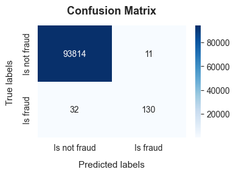

```python
plot_confusion_matrix(Y_test, light_gbm["y_proba"] >= light_gbm["metrics"][light_gbm["metrics"]["RecallScore"] >= 0.8].sort_values("F1Score", ascending=False)["Threshold"].iloc[0])
```

# Model Comparison and Selection

The next step is to define the desired model outcome. If minimizing false positives is the priority in fraud detection, then configurations with higher precision should be preferred. However, this comes at the cost of increased false negatives, meaning that more fraudulent transactions may go undetected. Conversely, if the objective is to detect as many fraudulent cases as possible, configurations with higher recall should be implemented. This approach reduces missed fraud but increases the number of false positives. The choice between these approaches depends on the requirements and risk tolerance of the decision-makers.

Model selection is performed by first enforcing a minimum Recall of 0.8, ensuring that a sufficient proportion of fraudulent transactions are detected. Among the models satisfying this constraint, the one with the highest F1 Score is selected, as it provides the best balance between precision and recall. This approach aligns model performance with the business objective of maximizing fraud detection while controlling the number of false positives. This two-step selection process reflects a practical decision framework, where recall acts as a hard requirement and F1 Score is used for performance optimization within that constraint.

```python
def model_comparison():
    df_all = []

    for name, model in models.items():
        df = model["metrics"].copy()
        df["Model"] = name
        cols = ["Threshold", "PrecisionScore", "RecallScore", "F1Score", "TP", "TN", "FP", "FN", "MCC"]
        df = df[["Model"] + [c for c in cols if c in df.columns]]
        logloss = log_loss(Y_test, model["y_proba"])
        brier = brier_score_loss(Y_test, model["y_proba"])
        roc = roc_auc_score(Y_test, model["y_proba"])
        pr = average_precision_score(Y_test, model["y_proba"])
        df["LogLoss"] = logloss
        df["BrierScoreLoss"] = brier
        df["ROC_AUC"] = roc
        df["PR_AUC"] = pr
        df_all.append(df)

    df_all = pd.concat(df_all).reset_index(drop=True)

    models_best_performance = df_all[df_all["RecallScore"] >= 0.80].sort_values("F1Score", ascending=False).drop_duplicates("Model").reset_index(drop=True)

    return { "models_best_performance": models_best_performance, "comparison_across_threshold": df_all }

df_comparison = model_comparison()
```

```python
df_comparison["models_best_performance"]
```

|  | Model | Threshold | PrecisionScore | RecallScore | F1Score | TP | TN | FP | FN | MCC | LogLoss | BrierScoreLoss | ROC_AUC | PR_AUC |
| --- | --- | --- | --- | --- | --- | --- | --- | --- | --- | --- | --- | --- | --- | --- |
| 0 | LightGBM | 0.76 | 0.921986 | 0.802469 | 0.858086 | 130 | 93814 | 11 | 32 | 0.859932 | 0.003985 | 0.000460 | 0.957675 | 0.840152 |
| 1 | Random Forest | 0.55 | 0.866667 | 0.802469 | 0.833333 | 130 | 93805 | 20 | 32 | 0.833676 | 0.004640 | 0.000529 | 0.976436 | 0.824583 |
| 2 | XGBoost | 0.69 | 0.791667 | 0.820988 | 0.806061 | 133 | 93790 | 35 | 29 | 0.805853 | 0.006056 | 0.000787 | 0.982098 | 0.811470 |
| 3 | Logistic Regression | 0.37 | 0.734463 | 0.802469 | 0.766962 | 130 | 93778 | 47 | 32 | 0.767296 | 0.006200 | 0.000751 | 0.969423 | 0.728130 |

The LightGBM model provides the strongest overall balance between precision and recall, achieving the best F1 Score and PR-AUC, which are particularly relevant under extreme class imbalance. This suggests that LightGBM offers the most effective trade-off between correctly identifying fraudulent transactions and limiting false positives, particularly at higher decision thresholds where maintaining strong recall becomes more challenging. LightGBM also achieves the lowest LogLoss, indicating that its predicted probabilities are well aligned with the observed outcomes, although this is secondary to recall performance in the fraud detection context.

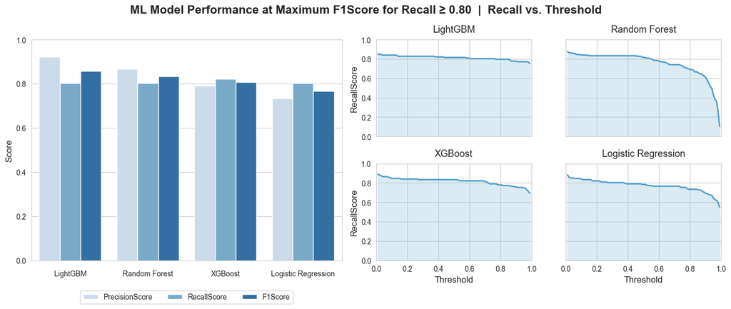

```python
def plot_model_comparison():

    fig = plt.figure(figsize=(14, 6))
    fig.suptitle( "ML Model Performance at Maximum F1Score for Recall ≥ 0.80  |  Recall vs. Threshold", y=0.98, fontsize=16, fontweight="bold" )
    gs = gridspec.GridSpec(2, 3, width_ratios=[2, 1, 1])

    df_comparison_filtered = df_comparison["comparison_across_threshold"][df_comparison["comparison_across_threshold"]["Model"].isin(list(df_comparison["models_best_performance"]["Model"].head(4)))]
    data = df_comparison_filtered[~df_comparison_filtered["Threshold"].isin([0.0, 1.0])]

    df_melt = df_comparison["models_best_performance"].head(4).melt(
        id_vars="Model",
        value_vars=["PrecisionScore", "RecallScore", "F1Score"]
    )

    ax_main = fig.add_subplot(gs[:, 0])

    sns.barplot(
        data=df_melt,
        x="Model",
        y="value",
        hue="variable",
        ax=ax_main,
        palette="Blues" # "Reds", "Oranges", "Greens", "Purples", "Greys", "deep", "muted", "dark", "colorblind",
    )

    ax_main.set_ylabel("Score", fontsize=12)
    ax_main.set_ylim(0, 1)
    ax_main.set_xlabel("")
    ax_main.tick_params(axis='x', rotation=0, pad=10)
    ax_main.legend(loc="upper center", bbox_to_anchor=(0.5, -0.12), ncol=df_melt["variable"].nunique())

    ax1 = fig.add_subplot(gs[0, 1])
    ax2 = fig.add_subplot(gs[0, 2], sharey=ax1)
    ax3 = fig.add_subplot(gs[1, 1], sharex=ax1)
    ax4 = fig.add_subplot(gs[1, 2], sharex=ax2, sharey=ax3)
    axes_right = [ax1, ax2, ax3, ax4]

    for ax in [ax1, ax2]:
        ax.tick_params(labelbottom=False)
    for ax in [ax2, ax4]:
        ax.tick_params(labelleft=False)

    models = df_comparison["models_best_performance"]["Model"].head(4)

    for ax, model in zip(axes_right, models):

        data_model = data[data["Model"] == model]
        df_long = data_model.melt(
            id_vars="Threshold",
            value_vars=["RecallScore"],
            var_name="Metric",
            value_name="Score"
        )

        palette = sns.color_palette("Blues")
        sns.lineplot(
            data=df_long,
            x="Threshold",
            y="Score",
            ax=ax,
            color=palette[3],
            linewidth=2
        )

        ax.set_title(model, fontsize=13, pad=10)
        ax.fill_between( df_long["Threshold"], df_long["Score"], color=palette[2], alpha=0.3 )
        ax.set_ylim(0, 1)
        ax.set_xlim(0, 1)
        ax.set_xlabel("Threshold", fontsize=12)
        ax.set_ylabel("RecallScore", fontsize=12)

    plt.tight_layout()
    plt.show()

plot_model_comparison()
```

The Random Forest model closely follows LightGBM, showing excellent performance across all metrics and even outperforming it in ROC-AUC. This indicates strong ranking capability and similar sensitivity to fraudulent transactions, but with less optimal precision–recall balance.

XGBoost also performs well, maintaining competitive with the best recall and ROC_AUC, but with a significant lower precision–recall balance compared to the two leading models. Logistic Regression shows the weakest performance, reinforcing that linear decision boundaries are insufficient to capture the nonlinear structure and complexity of fraud patterns in this dataset.

Overall, tree-based ensemble methods clearly outperform Logistic Regression, highlighting the importance of nonlinear modeling and feature interaction capture in fraud detection tasks.

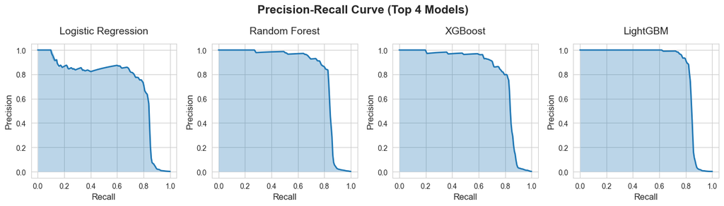

```python
def model_precision_recall_curve():

    fig, axes = plt.subplots(1, 4, figsize=(14, 4))

    for i, (name, model) in enumerate(models.items()):
        precision, recall, _ = precision_recall_curve(Y_test, model["y_proba"])
        df = pd.DataFrame({"precision": precision, "recall": recall})
        sns.lineplot(
            data=df,
            x="recall",
            y="precision",
            ax=axes[i],
            linewidth=2
        )

        axes[i].fill_between( df["recall"], df["precision"], alpha=0.3 )
        axes[i].set_title(f"{name}", fontsize=14, pad=14)
        axes[i].set_xlabel("Recall", fontsize=12)
        axes[i].set_ylabel("Precision", fontsize=12)

    plt.suptitle("Precision-Recall Curve (Top 4 Models)", y=0.98, fontsize=16, fontweight="bold")
    plt.tight_layout()
    plt.show()

model_precision_recall_curve()
```

While ROC-AUC remains high across all models, PR-AUC provides a more meaningful evaluation under extreme class imbalance (0.17% fraud rate), as it better reflects performance on the minority class. Under this metric, LightGBM shows the best performance, followed by Random Forest.

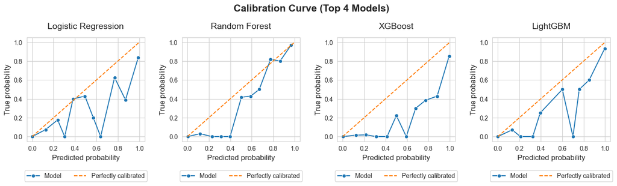

```python
def model_calibration_curve():

    fig, axes = plt.subplots(1, 4, figsize=(14, 4.5))

    for i, (name, model) in enumerate(models.items()):
        bins = 11
        prob_true, prob_pred = calibration_curve(Y_test, model["y_proba"], n_bins=bins)
        df = pd.DataFrame({"prob_true": prob_true, "prob_pred": prob_pred})

        sns.lineplot(
            data=df,
            x="prob_pred",
            y="prob_true",
            ax=axes[i],
            marker='o',
            label="Model"
        )

        sns.lineplot(
            x=[0, 1],
            y=[0, 1],
            ax=axes[i],
            linestyle='--',
            label="Perfectly calibrated"
        )

        axes[i].set_title(f"{name}", fontsize=14, pad=14)
        axes[i].set_xlabel("Predicted probability", fontsize=12)
        axes[i].set_ylabel("True probability", fontsize=12)
        axes[i].legend(loc="upper center", bbox_to_anchor=(0.5, -0.25), ncol=4)

    plt.suptitle("Calibration Curve (Top 4 Models)", y=0.98, fontsize=16, fontweight="bold")
    plt.tight_layout()
    plt.show()

model_calibration_curve()
```

The calibration curve exhibits some variability due to class imbalance and limited observations within probability bins. While Random Forest provides smoother and well-calibrated probabilities, LightGBM achieves better overall predictive performance, highlighting a trade-off between calibration and classification effectiveness. LightGBM also achieves lower Log Loss, indicating that the model produces well-calibrated probability estimates overall.

The transaction amount has a relatively limited impact, with only a small number of high-value observations contributing to an increased probability of fraud. This indicates that fraud in this dataset is not strongly dependent on transaction size.

Overall, the model captures fraud patterns through a combination of directional effects and nonlinear relationships across a small number of influential features.

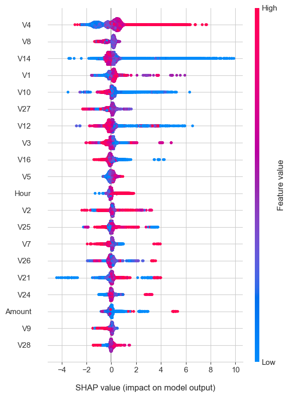

```python
def features_impact(model):
    warnings.filterwarnings("ignore", message="LightGBM binary classifier with TreeExplainer shap values output has changed")
    explainer = shap.TreeExplainer(model)
    shap_values = explainer.shap_values(X_test)
    return shap_values

def plot_summary_plot(model):
    shap_values = features_impact(model)
    shap.summary_plot(shap_values, X_test, plot_size=(6, 8), show=False)
    ax = plt.gca()
    ax.tick_params(axis='y', labelsize=11)
    ax.tick_params(axis='x', labelsize=11)
    plt.xlabel("SHAP value (impact on model output)", fontsize=12, labelpad=15)
    plt.tight_layout()
    plt.show()

plot_summary_plot(models[df_comparison["models_best_performance"]["Model"].iloc[0]]['best_model'])
```

The SHAP dependence plot shows how the contribution of feature V14 to the model prediction varies across its value range, while coloring by V4, the feature with the strongest interaction with V14. Different values of V4 are associated with different SHAP effects of V14: when V4 is higher (red dots), V14 tends to have more positive SHAP values (stronger positive contribution to the prediction), whereas lower values of V4 (blue dots) are more associated with neutral contributions from V14. This suggests a strong interaction between V14 and V4, meaning the effect of V14 on the model output is conditional on the value of V4.

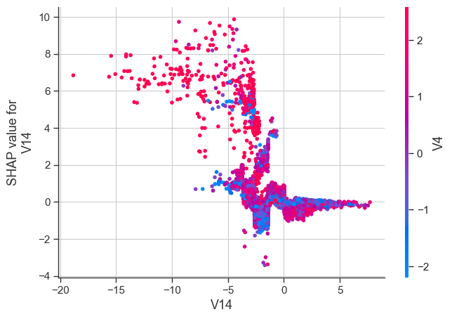

```python
shap.dependence_plot("V14", features_impact(models[df_comparison["models_best_performance"]["Model"].iloc[0]]['best_model']), X_test)
```